# Data Camp / Intro to Time Series Analysis - Chapter 3

Initialize and load the data

Chapter 3 of [Data Camp - Intro to Time Series Analsys](https://www.datacamp.com/courses/introduction-to-time-series-analysis)

## Scatterplots

### Log returns

apply `diff(log(stock_price))` to each stock, then bind them with `cbind()` and plot.

*Log Returns* or *continuously compounded returns* are a commonly used value in financial time series analysis. They are to log of gross returns.

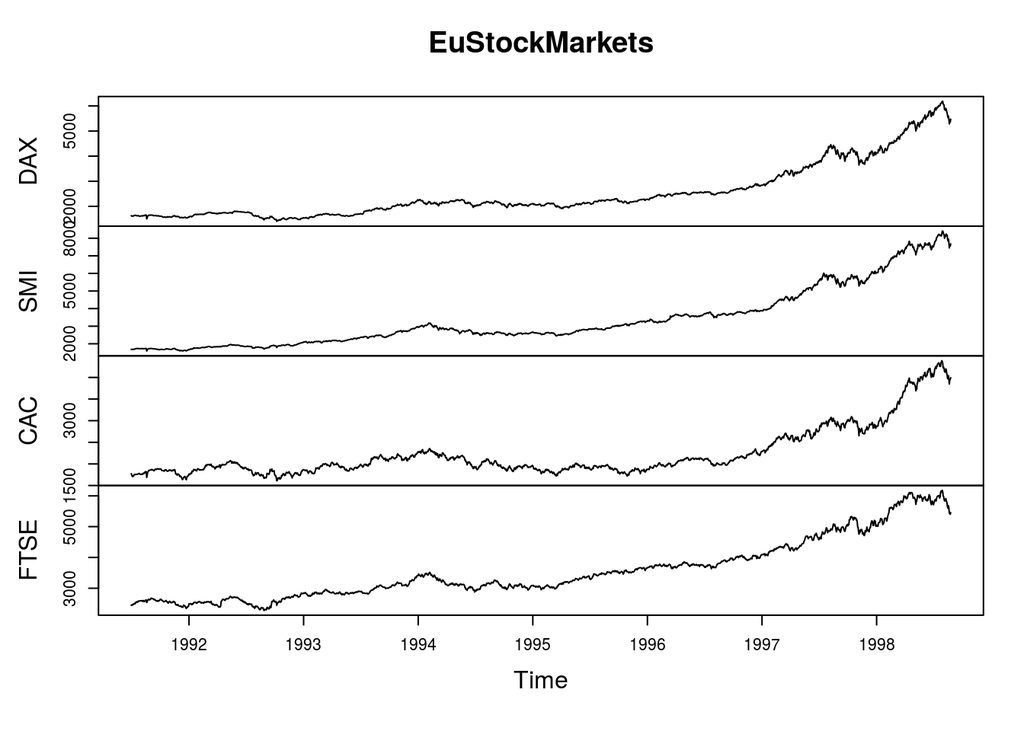

```r
data("EuStockMarkets")

plot(EuStockMarkets)
```

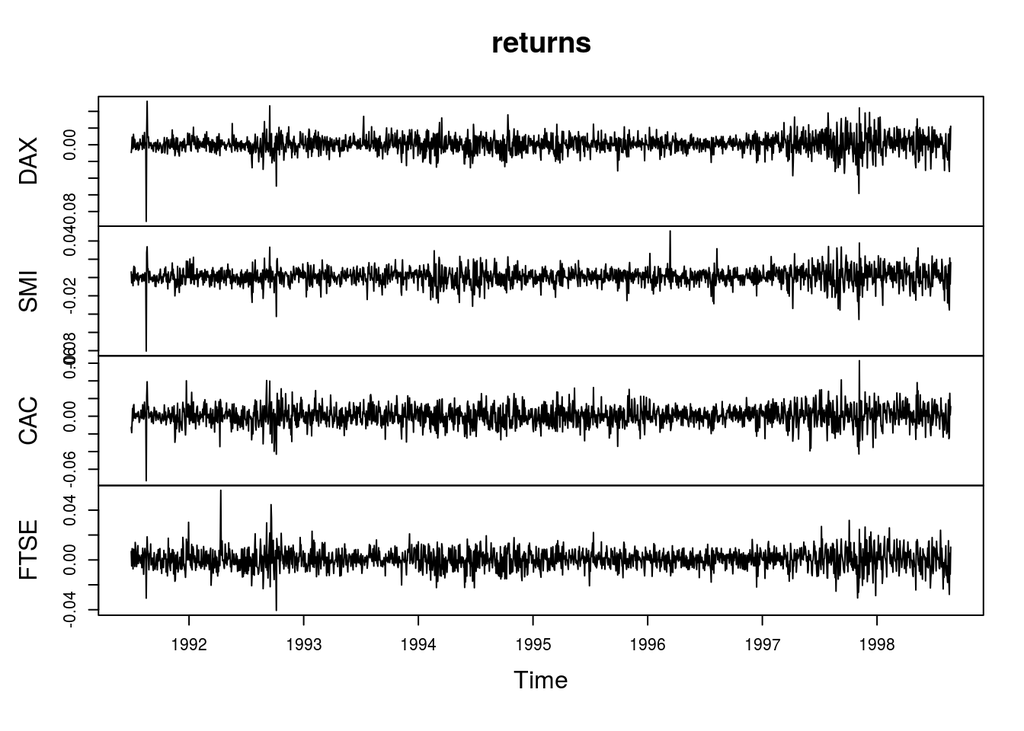

```r
# Use this code to convert prices to returns
returns <- EuStockMarkets[-1,] / EuStockMarkets[-1860,] - 1

# Convert returns to ts
returns <- ts(returns, start = c(1991, 130), frequency = 260)

# Plot returns
plot(returns)
```

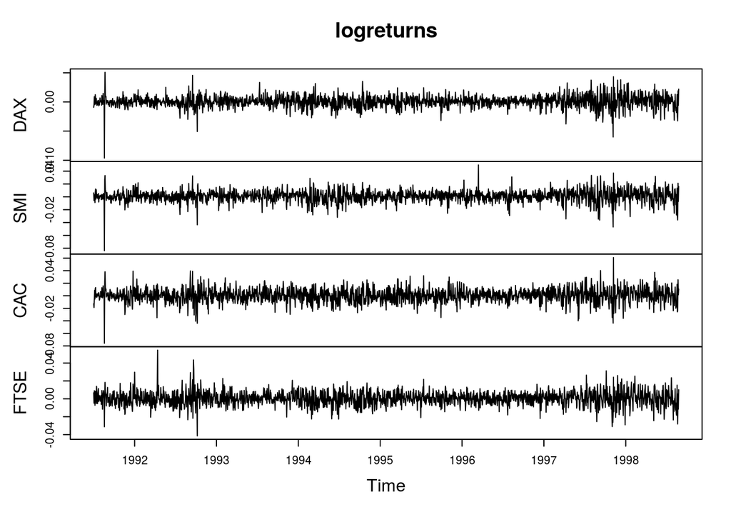

```r
# Use this code to convert prices to log returns
logreturns <- diff(log(EuStockMarkets))

# Plot logreturns
plot(logreturns)
```

### Calculating column stats

See the `colMeans()`, `colSum()`, etc or the dot versions, `.colMeans()` for calculating column or row statistics on a dataset.

### Covariance

`cov()` is used to calculate the *covariance* between to datasets which are related over time. Positive covariance implies a positive relationship. *Covariance* measures teh strength of the linear relationship between matched pairs of variables.

*covariance* are dependant on the size of the values. So it’s hard to interpret the value.

### Correlations

- Standardized version of *covariance* between -1 and 1.
- +1 is perfect positive linear relationship
- -1 is perfect negative linear relationship
- - is no linear relationship

`cor()` is used to calculate the *correlation*. This is the *covariance* divided by the product of the *sd* of the 2 inputs. e.g. `cov(stock_a, stock_b) / (sd(stock_a) * sd(stock_b))`.

`cor()` and `cov()` can be used on 2 time series or on a matrix with multiple colums to compare.

```r
DAX_logreturns <- ts(diff(log(EuStockMarkets[,'DAX'])), start=c(1991, 131), frequency=260)
FTSE_logreturns <- ts(diff(log(EuStockMarkets[,'FTSE'])), start=c(1991, 131), frequency=260)

cov(DAX_logreturns, FTSE_logreturns)
```

```
## [1] 5.241794e-05
```

```r
# Use cov() with logreturns
cov(logreturns)
```

```
##               DAX          SMI          CAC         FTSE
## DAX  1.061072e-04 6.699564e-05 8.345130e-05 5.241794e-05
## SMI  6.699564e-05 8.556317e-05 6.285881e-05 4.304517e-05
## CAC  8.345130e-05 6.285881e-05 1.216802e-04 5.693174e-05
## FTSE 5.241794e-05 4.304517e-05 5.693174e-05 6.332543e-05
```

```r
# Use cor() with DAX_logreturns and FTSE_logreturns
cor(DAX_logreturns, FTSE_logreturns)
```

```
## [1] 0.6394674
```

```r
# Use cor() with logreturns
cor(logreturns)
```

```
##            DAX       SMI       CAC      FTSE
## DAX  1.0000000 0.7031219 0.7344304 0.6394674
## SMI  0.7031219 1.0000000 0.6160454 0.5847791
## CAC  0.7344304 0.6160454 1.0000000 0.6485679
## FTSE 0.6394674 0.5847791 0.6485679 1.0000000
```

### Autocorrelation

A means to determine how a value relates to a previous value.

Autocorelation at lag 1 is comparing current value to the previous, lag=2 todays prior.

### The AutoCorrelation Function (ACF)

The `acf()` function calculates the Autocorrelation for a series based on the indicated lag. It will also plot the autocorrelation(s) if *plot=TRUE* is set. If no lag is specified, it will calculate 0 - 10.

**NOTE:** acf calculates the correlation using 1/n, which is preferable for time series, wherase the `cor()` function uses 1/n-1. This means that the `acf()` value is close but off by a factor of n-1/n.

```r
x = ts(arima.sim(model=list(order=c(0,0,0)), n=150),
        start=1, frequency=1)

x0 = x[-1]
x1 = x[-150]

head(cbind(x0, x1))
```

```
##              x0         x1
## [1,]  0.2654861  0.3786456
## [2,] -0.1756523  0.2654861
## [3,] -0.2358109 -0.1756523
## [4,]  0.6100009 -0.2358109
## [5,] -0.1463352  0.6100009
## [6,]  0.5508207 -0.1463352
```

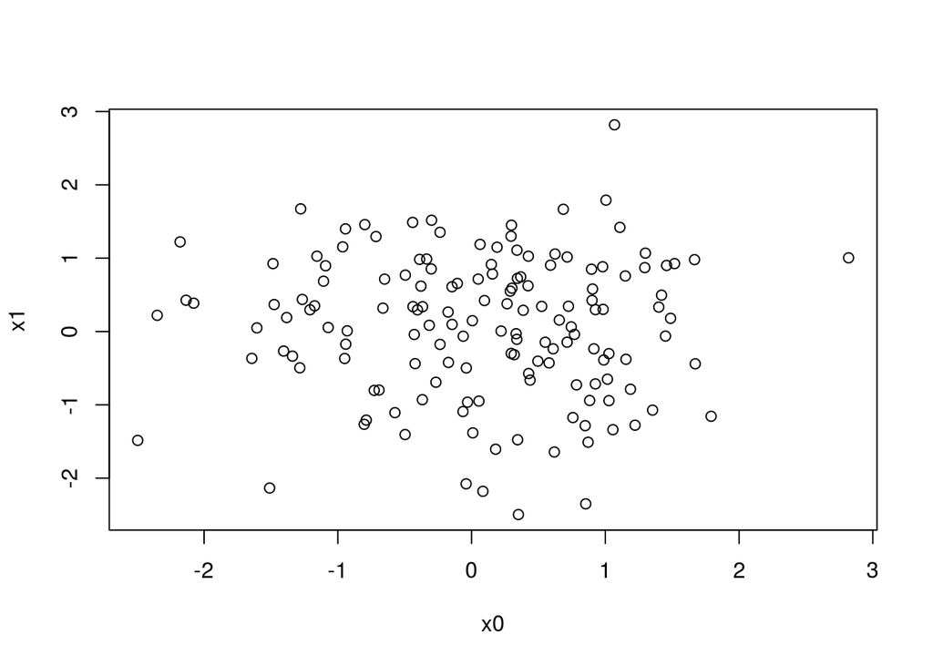

```r
plot(x0, x1)
```

```r
cor(x0, x1)
```

```
## [1] -0.01961494
```

```r
acf(x, lag.max = 1, plot=FALSE)
```

```
##
## Autocorrelations of series 'x', by lag
##
##     0     1
##  1.00 -0.02
```

```r
cor(x0, x1) * (149 / 150)
```

```
## [1] -0.01948417
```